# Práctica 2: Limpieza y análisis de datos

Maite Gracia

4 de January, 2021

# 1 Descripción del dataset

Se ha decidido utilizar un dataset de la web Kaggle para la presente práctica. **[enlace]**(https://www.kaggle.com/kemical/kickstarter-projects) Kickstarter es una plataforma de micro mecenazgo, es decir, gente de todo el mundo ayuda a financiar las ideas y proyectos de pequeñas empresas o particulares.

En la web de Kickstarter **[enlace]**(https://www.kickstarter.com/) se pueden encontrar miles de campañas que buscan financiación para desarrollar productos de todo tipo. Desde películas independientes, a juegos de mesa o ropa, peluches, libros etc. Cada una de estas campañas tendrá un periodo de tiempo en el que cualquiera podrá aportar dinero al proyecto y si se consigue llegar al objetivo de dinero propuesto la campaña será fundada.

Yo personalmente utilicé Kickstarter hace unos años para lanzar una serie de productos lo cual es una de las razones por las que he elegido el presente dataset. El objetivo principal sería poder crear un modelo que predijera que probabilidad tiene cualquier tipo de producto de conseguir recaudar dinero mediante una campaña de Kickstarter antes de ser lanzado.

# 2 Integración y selección de los datos de interés a analizar

Las variables que componen el dataset son:

- ID: identificador interno de Kickstarter
- name: nombre del proyecto
- category: categoría específica en la que se encuentra el proyecto
- main_category: categoría principal de la campaña
- currency: divisa en la que se creó el proyecto
- deadline: fecha límite
- goal: cantidad de dinero que el creador necesita para completar el proyecto
- launched: fecha lanzamiento
- pledged: cantidad total aportada al proyecto
- state: condición en la que se encuentra el Proyecto (failed, successful, canceled, live, undefined)
- backers: total de mecenas.
- country: país en el que se encuentra el Proyecto.
- usd_pledged: conversión en dólares de la columna pledged hecha por Kickstarter
- usd_pledged_real: conversión en dólares de la columna pledged hecha a través de Fixer.io API
- usd_goal_real: conversión en dólares de la columna goal hecha a través de Fixer.io API

Antes de cargar el archivo en R se hace una inspección de los datos. Al tratarse de un archivo con extensión .csv, hay que cerciorarse del tipo de separador utilizado (en este caso la “,”) y posteriormente se procede a su carga teniendo en cuenta el separador antes mencionado:

```r
# Asignamos los datos del fichero cargado a una variable denominada dataSet
dataSet <- read.csv('../data/ks-projects-201801.csv')
nrow(dataSet)
```

```
## [1] 378661
```

```r
names(dataSet)
```

```
##  [1] "ID"               "name"             "category"         "main_category"
##  [5] "currency"         "deadline"         "goal"             "launched"
##  [9] "pledged"          "state"            "backers"          "country"
## [13] "usd.pledged"      "usd_pledged_real" "usd_goal_real"
```

Vemos que el dataset original se compone de 378,661 muestras y 15 variables. Ya que se trata de una cantidad de muestras muy elevadas, se ha decidido aplicar una técnica para reducir la cantidad de estas, se empleará la técnica de muestreo aleatorio simple sin sustitución, es decir, se van a extraer 3000 muestras aleatorias del conjunto de datos, donde la probabilidad de escoger cada una de las muestras será la misma para todas, 1/378,661.

```r
library(sampling)
indices <- sample( 1:nrow( dataSet ), 3000 )
dataSet <- dataSet[ indices, ]
```

A partir de ahora cuando se haga referencia al dataset, estaremos hablando del dataset que cotiene las 3000 muestras, no el dataset original.

# 3 Limpieza de los datos

```r
# Muestra de las 5 primeras líneas del dataset completo
head(dataSet, 5)
```

```
##                ID                                                       name
## 347888   84222217                         A New Way To Wear Denim (Canceled)
## 268563  436569651                                            2017 WiFi Badge
## 40551  1206305470                  WinePerfect - The Perfect Wine Experience
## 288228  536491740 It's not the Beverly Hillbillies: How Appalachia Really is
## 3247   1016760870                                                      Pívol
##          category main_category currency   deadline  goal            launched
## 347888    Fashion       Fashion      USD 2014-09-15  5000 2014-08-01 16:02:17
## 268563  Wearables    Technology      USD 2017-07-11  4500 2017-06-26 19:04:36
## 40551        Food          Food      CAD 2013-10-17 25000 2013-09-12 06:02:52
## 288228      Photo    Journalism      USD 2016-08-23  2500 2016-07-09 23:08:30
## 3247   Technology    Technology      MXN 2017-11-25 60000 2017-10-26 18:16:31
##         pledged      state backers country usd.pledged usd_pledged_real
## 347888   307.00   canceled       2      US      307.00           307.00
## 268563 13464.66 successful     241      US      330.00         13464.66
## 40551   1973.00     failed      41      CA     1906.38          1916.28
## 288228    83.50     failed       7      US        0.00            83.50
## 3247       0.00     failed       0      MX        0.00             0.00
##        usd_goal_real
## 347888       5000.00
## 268563       4500.00
## 40551       24281.27
## 288228       2500.00
## 3247         3213.02
```

```r
# Análisis descriptivo del dataset
summary(dataSet)
```

```
##        ID                name             category         main_category
##  Min.   :9.216e+04   Length:3000        Length:3000        Length:3000
##  1st Qu.:5.586e+08   Class :character   Class :character   Class :character
##  Median :1.097e+09   Mode  :character   Mode  :character   Mode  :character
##  Mean   :1.083e+09
##  3rd Qu.:1.610e+09
##  Max.   :2.147e+09
##
##    currency           deadline              goal            launched
##  Length:3000        Length:3000        Min.   :       1   Length:3000
##  Class :character   Class :character   1st Qu.:    2000   Class :character
##  Mode  :character   Mode  :character   Median :    5000   Mode  :character
##                                        Mean   :   35574
##                                        3rd Qu.:   15275
##                                        Max.   :20000000
##
##     pledged           state              backers           country
##  Min.   :      0   Length:3000        Min.   :    0.00   Length:3000
##  1st Qu.:     26   Class :character   1st Qu.:    2.00   Class :character
##  Median :    580   Mode  :character   Median :   11.00   Mode  :character
##  Mean   :   7860                      Mean   :   95.56
##  3rd Qu.:   3847                      3rd Qu.:   53.00
##  Max.   :1209423                      Max.   :16335.00
##
##   usd.pledged        usd_pledged_real    usd_goal_real
##  Min.   :      0.0   Min.   :      0.0   Min.   :       1
##  1st Qu.:     16.9   1st Qu.:     26.8   1st Qu.:    2000
##  Median :    385.0   Median :    601.8   Median :    5183
##  Mean   :   5806.2   Mean   :   7232.6   Mean   :   33964
##  3rd Qu.:   3022.5   3rd Qu.:   3839.8   3rd Qu.:   15009
##  Max.   :1209423.1   Max.   :1209423.1   Max.   :20000000
##  NA's   :29
```

```r
# Comprobamos si hay NA en el dataset original
sapply(dataSet, function(x) sum(is.na(x)))
```

```
##               ID             name         category    main_category
##                0                0                0                0
##         currency         deadline             goal         launched
##                0                0                0                0
##          pledged            state          backers          country
##                0                0                0                0
##      usd.pledged usd_pledged_real    usd_goal_real
##               29                0                0
```

## 3.1 Normalización de los datos

- Variables category, main_category, currency y country van a convertirse a tipo factor para poder agrupar proyectos.

```r
dataSet$category <- as.factor(dataSet$category)
dataSet$main_category <- as.factor(dataSet$main_category)
dataSet$currency <- as.factor(dataSet$currency)
dataSet$country <- as.factor(dataSet$country)
dataSet$state <- as.factor(dataSet$state)

# Valores que toman las variables currency y country
unique(dataSet$currency)
```

```
##  [1] USD CAD MXN GBP EUR AUD SEK NZD DKK HKD NOK CHF SGD
## Levels: AUD CAD CHF DKK EUR GBP HKD MXN NOK NZD SEK SGD USD
```

```r
unique(dataSet$country)
```

```
##  [1] US   CA   MX   GB   ES   N,0" BE   AU   SE   NZ   NL   FR   IT   DK   DE
## [16] HK   AT   NO   CH   IE   SG
## Levels: AT AU BE CA CH DE DK ES FR GB HK IE IT MX N,0" NL NO NZ SE SG US
```

Vemos que country tiene un carácter especial en algunos de los casos, vamos a sustituirlos por NA y más adelante imputaremos estos valores basándonos en la variable currency.

```r
dataSet$country[dataSet$country == 'N,0"'] <- NA
```

- Las variables deadline y launched se convertirán a tipo Date.

```r
dataSet$deadline <- as.Date(dataSet$deadline, '%Y-%m-%d')
dataSet$launched <- as.Date(dataSet$launched, '%Y-%m-%d')
```

- goal, pledged y usd.pledged van a pasar a ser tipo numérico.

```r
dataSet$goal <- as.numeric(dataSet$goal)
dataSet$pledged <- as.numeric(dataSet$pledged)
dataSet$usd_pledged <- as.numeric(dataSet$usd_pledged)
dataSet$usd_pledged_real <- as.numeric(dataSet$usd_pledged_real)
dataSet$usd_goal_real <- as.numeric(dataSet$usd_goal_real)
```

```r
dataSet['status'] <- as.factor(
  ifelse(
    (dataSet$pledged > dataSet$goal) &
    (dataSet$state != 'live' | dataSet$state != 'undefined'),
         1, 0))
```

- Se va a añadir una columna nueva euros_pledged que contendrá la conversión de usd_pledged_real a euros. Se utilizará la conversión 1€ = 1.23$ a 4 de enero de 2021.

```r
dataSet['euros_pledged'] <- as.numeric(
  format(as.numeric(dataSet$usd_pledged_real)/1.23), nsmall = 1)
```

- Se va a añadir una columna nueva euros_goal que contendrá la conversión de goal a euros. Se utilizará la conversión 1€ = 1.23$ a 4 de enero de 2021.

```r
dataSet['euros_goal'] <- round(as.numeric(
  format(as.numeric(dataSet$goal)/1.23), nsmall = 1), 2)
```

- Se va a añadir una columna nueva proyect_length de tipo numérico, que contendrá el total de días que el proyecto ha estado abierto a financiación. Esta nueva columna será resultado de la diferencia entre la columna deadline y launched.

```r
dataSet['proyect_length'] <- as.numeric(dataSet$deadline - dataSet$launched)
```

```r
# Muestra set de datos
head(dataSet, 5)
```

```
##                ID                                                       name
## 347888   84222217                         A New Way To Wear Denim (Canceled)
## 268563  436569651                                            2017 WiFi Badge
## 40551  1206305470                  WinePerfect - The Perfect Wine Experience
## 288228  536491740 It's not the Beverly Hillbillies: How Appalachia Really is
## 3247   1016760870                                                      Pívol
##          category main_category currency   deadline  goal   launched  pledged
## 347888    Fashion       Fashion      USD 2014-09-15  5000 2014-08-01   307.00
## 268563  Wearables    Technology      USD 2017-07-11  4500 2017-06-26 13464.66
## 40551        Food          Food      CAD 2013-10-17 25000 2013-09-12  1973.00
## 288228      Photo    Journalism      USD 2016-08-23  2500 2016-07-09    83.50
## 3247   Technology    Technology      MXN 2017-11-25 60000 2017-10-26     0.00
##             state backers country usd.pledged usd_pledged_real usd_goal_real
## 347888   canceled       2      US      307.00           307.00       5000.00
## 268563 successful     241      US      330.00         13464.66       4500.00
## 40551      failed      41      CA     1906.38          1916.28      24281.27
## 288228     failed       7      US        0.00            83.50       2500.00
## 3247       failed       0      MX        0.00             0.00       3213.02
##        usd_pledged status euros_pledged euros_goal proyect_length
## 347888      307.00      0     249.59350    4065.04             45
## 268563    13464.66      1   10946.88000    3658.54             15
## 40551      1916.28      0    1557.95100   20325.20             35
## 288228       83.50      0      67.88618    2032.52             45
## 3247          0.00      0       0.00000   48780.49             30
```

```r
summary(dataSet)
```

```
##        ID                name                     category
##  Min.   :9.216e+04   Length:3000        Product Design: 181
##  1st Qu.:5.586e+08   Class :character   Music         : 129
##  Median :1.097e+09   Mode  :character   Documentary   : 126
##  Mean   :1.083e+09                      Tabletop Games: 115
##  3rd Qu.:1.610e+09                      Video Games   :  97
##  Max.   :2.147e+09                      Film & Video  :  92
##                                         (Other)       :2260
##       main_category     currency       deadline               goal
##  Film & Video: 492   USD    :2337   Min.   :2009-07-14   Min.   :       1
##  Music       : 405   GBP    : 274   1st Qu.:2013-06-03   1st Qu.:    2000
##  Publishing  : 308   CAD    : 125   Median :2015-01-18   Median :    5000
##  Games       : 287   EUR    : 125   Mean   :2014-11-01   Mean   :   35574
##  Technology  : 258   AUD    :  69   3rd Qu.:2016-04-25   3rd Qu.:   15275
##  Design      : 247   MXN    :  16   Max.   :2018-02-14   Max.   :20000000
##  (Other)     :1003   (Other):  54
##     launched             pledged               state         backers
##  Min.   :2009-05-05   Min.   :      0   canceled  : 312   Min.   :    0.00
##  1st Qu.:2013-05-05   1st Qu.:     26   failed    :1575   1st Qu.:    2.00
##  Median :2014-12-15   Median :    580   live      :  22   Median :   11.00
##  Mean   :2014-09-27   Mean   :   7860   successful:1052   Mean   :   95.56
##  3rd Qu.:2016-03-21   3rd Qu.:   3847   suspended :  12   3rd Qu.:   53.00
##  Max.   :2018-01-02   Max.   :1209423   undefined :  27   Max.   :16335.00
##
##     country      usd.pledged        usd_pledged_real    usd_goal_real
##  US     :2312   Min.   :      0.0   Min.   :      0.0   Min.   :       1
##  GB     : 271   1st Qu.:     16.9   1st Qu.:     26.8   1st Qu.:    2000
##  CA     : 124   Median :    385.0   Median :    601.8   Median :    5183
##  AU     :  69   Mean   :   5806.2   Mean   :   7232.6   Mean   :   33964
##  FR     :  25   3rd Qu.:   3022.5   3rd Qu.:   3839.8   3rd Qu.:   15009
##  (Other): 170   Max.   :1209423.1   Max.   :1209423.1   Max.   :20000000
##  NA's   :  29   NA's   :29
##   usd_pledged        status   euros_pledged        euros_goal
##  Min.   :      0.0   0:1959   Min.   :     0.0   Min.   :       1
##  1st Qu.:     26.8   1:1041   1st Qu.:    21.7   1st Qu.:    1626
##  Median :    601.8            Median :   489.3   Median :    4065
##  Mean   :   7232.6            Mean   :  5880.2   Mean   :   28922
##  3rd Qu.:   3839.8            3rd Qu.:  3121.8   3rd Qu.:   12419
##  Max.   :1209423.1            Max.   :983270.9   Max.   :16260160
##
##  proyect_length
##  Min.   : 2.00
##  1st Qu.:30.00
##  Median :30.00
##  Mean   :34.33
##  3rd Qu.:40.00
##  Max.   :91.00
##
```

## 3.2 Valores atípicos

Volviendo a la estadística descriptiva vemos que la diferencia entre la media y el máximo y mínimo valor de muestras de la variable pledged y proyect_length es bastante significativa, lo que puede indicar la presencia de outliers. Vamos a comprobar si tenemos outliers mediante diagrama de cajas.

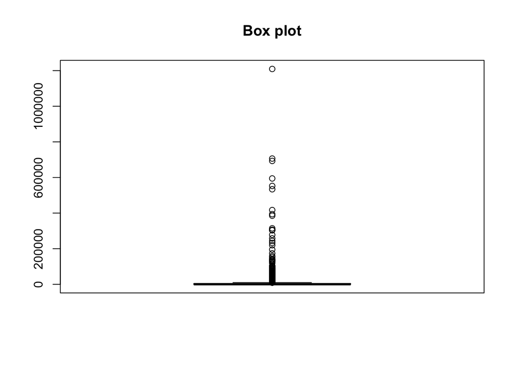

```r
# Importamos la librería ggplot2
library(ggplot2)

# Diagrama de cajas para la variable pledged y proyect_length
boxplot(dataSet$pledged, main="Box plot", col="gray")
```

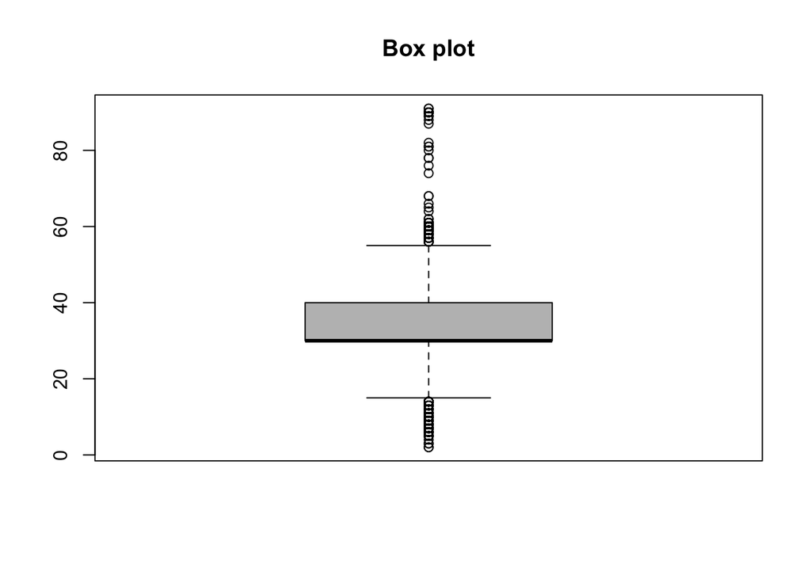

```r
boxplot(dataSet$proyect_length, main="Box plot", col="gray")
```

Vemos que ambas variables tienen valores extremos por lo que vamos a analizar para determinar cómo proceder con ellos.

```r
tail(sort(dataSet$pledged), 10)
```

```
##  [1]  314547.5  385361.5  394019.7  416986.9  533837.0  552501.0  594559.0
##  [8]  692912.0  706287.0 1209423.1
```

```r
tail(sort(dataSet$proyect_length), 10)
```

```
##  [1] 90 90 90 90 90 90 90 90 91 91
```

Vemos que hay bastante diferencia entre la media de la variable pledged y los valores más altos, pero haciendo un poco de investigación online se ha encontrado que algún proyecto ha llegado a recaudar más de 20,000,000$, **[enlace]**(https://www.marketwatch.com/story/10-kickstarter-products-that-raised-the-most-money-2017-06-22-10883052). Por este motivo se ha decidido aceptar dichos outliers y tratarlos como datos válidos.

Haciendo un poco de investigación sobre la normativa de Kickstarter, se ha encontrado **[enlace]**(https://help.kickstarter.com/hc/en-us/articles/115005128434-What-is-the-maximum-project-duration-#:~:text=Projects%20on%20Kickstarter%20can%20last,at%2030%20days%20or%20less.) que, hoy en día, la duración máxima por proyecto es de 60 días. También en este otro artículo de explica que hasta el año 2011 la duración máxima era de 90 días **[enlace]**(https://www.kickstarter.com/blog/shortening-the-maximum-project-length).

Por ello se ha decidido que cualquier duración significativamente mayor de 90 días se va a tratar como outlier y se reemplazará por NA para posteriormente imputarlo con un valor de 90.

```r
dataSet$proyect_length <- ifelse(dataSet$proyect_length > 90, NA, dataSet$proyect_length)
index <- which(is.na(dataSet$proyect_length))
index
```

```
## [1]  265 1084
```

Muestra de todos las variables y sus valores NA’s.

```r
# Comprobamos si quedan NA's
sapply(dataSet, function(x) sum(is.na(x)))
```

```
##               ID             name         category    main_category
##                0                0                0                0
##         currency         deadline             goal         launched
##                0                0                0                0
##          pledged            state          backers          country
##                0                0                0               29
##      usd.pledged usd_pledged_real    usd_goal_real      usd_pledged
##               29                0                0                0
##           status    euros_pledged       euros_goal   proyect_length
##                0                0                0                2
```

## 3.3 Imputación de valores

- Cómo se ha mencionado anteriormente los valores NA de la variable proyect_length se van a reemplazar por 90 ya que es el máximo número de días que un proyecto puede estar recaudando dinero.

```r
dataSet$proyect_length[index] <- 90
```

- Imputación de valores perdidos para la variable country en base a la variable currency.

```r
idx <- which(is.na(dataSet$country))
# encontrar las combinaciones únicas de country y currency pero no cuando country
# es NA
uniques <- unique(dataSet[c('country', 'currency')])
uniques <- uniques[!is.na(uniques$country),]

# reemplazar los NA's de country con los valores únicos asociados con currency
na.country <- which(is.na(dataSet$country))
na.currency <- dataSet$currency[na.country]
dataSet$country[idx] <- uniques$country[match(na.currency, uniques$currency)]
```

Por último comprobamos si quedan NA’s en los datos.

```r
# Comprobamos si quedan NAs
sapply(dataSet, function(x) sum(is.na(x)))
```

```
##               ID             name         category    main_category
##                0                0                0                0
##         currency         deadline             goal         launched
##                0                0                0                0
##          pledged            state          backers          country
##                0                0                0                0
##      usd.pledged usd_pledged_real    usd_goal_real      usd_pledged
##               29                0                0                0
##           status    euros_pledged       euros_goal   proyect_length
##                0                0                0                0
```

## 3.4 Selección de datos

A continuación, vamos a detallar que atributos hemos descartado y cuales hemos decidido sean imprescindibles para el análisis:

- Se ha decidido borrar del dataset la columna de usd_pledged, esta representa la conversión a dólares por parte de Kickstarter del atributo pledged, pero se han descubierto bastantes inconsistencias. El creador del dataset, por este mismo motivo, decidió incluir un nuevo atributo con una conversión más precisa de pledged, que es la que vamos a usar.
- También se ha decidido descartar la variable usd_goal_pledged porque no resulta significativa para el estudio.
- Por otro lado, vamos a prescindir de la variable state. Como se ha mencionado anteriormente, un Kickstarter es satisfactorio si el proyecto consigue recaudar el dinero marcado como objetivo en el tiempo estimado, por lo que no es necesario para nuestro estudio si dicho proyecto se ha cancelado, o se ha suspendido o sigue activo. Se puede dar el caso por ejemplo que un proyecto llegue al objetivo económico marcado dentro de tiempo, pero el organizador, por cualquier motivo decida suspenderlo. En ese caso el proyecto aparecerá como cancelado, pero desde el punto de vista del objetivo del proyecto, la recaudación ha sido satisfactoria.

```r
# Quitar columnas usd_pledged y usd_goal_pledged del daataset
drops <- c('usd.pledged', 'usd_goal_pledged', 'state')
dataSet <- dataSet[ , !(names(dataSet) %in% drops)]
# Anális descriptivo del dataset limpio
summary(dataSet)
```

```
##        ID                name                     category
##  Min.   :9.216e+04   Length:3000        Product Design: 181
##  1st Qu.:5.586e+08   Class :character   Music         : 129
##  Median :1.097e+09   Mode  :character   Documentary   : 126
##  Mean   :1.083e+09                      Tabletop Games: 115
##  3rd Qu.:1.610e+09                      Video Games   :  97
##  Max.   :2.147e+09                      Film & Video  :  92
##                                         (Other)       :2260
##       main_category     currency       deadline               goal
##  Film & Video: 492   USD    :2337   Min.   :2009-07-14   Min.   :       1
##  Music       : 405   GBP    : 274   1st Qu.:2013-06-03   1st Qu.:    2000
##  Publishing  : 308   CAD    : 125   Median :2015-01-18   Median :    5000
##  Games       : 287   EUR    : 125   Mean   :2014-11-01   Mean   :   35574
##  Technology  : 258   AUD    :  69   3rd Qu.:2016-04-25   3rd Qu.:   15275
##  Design      : 247   MXN    :  16   Max.   :2018-02-14   Max.   :20000000
##  (Other)     :1003   (Other):  54
##     launched             pledged           backers            country
##  Min.   :2009-05-05   Min.   :      0   Min.   :    0.00   US     :2337
##  1st Qu.:2013-05-05   1st Qu.:     26   1st Qu.:    2.00   GB     : 274
##  Median :2014-12-15   Median :    580   Median :   11.00   CA     : 125
##  Mean   :2014-09-27   Mean   :   7860   Mean   :   95.56   AU     :  69
##  3rd Qu.:2016-03-21   3rd Qu.:   3847   3rd Qu.:   53.00   FR     :  25
##  Max.   :2018-01-02   Max.   :1209423   Max.   :16335.00   DE     :  24
##                                                            (Other): 146
##  usd_pledged_real    usd_goal_real       usd_pledged        status
##  Min.   :      0.0   Min.   :       1   Min.   :      0.0   0:1959
##  1st Qu.:     26.8   1st Qu.:    2000   1st Qu.:     26.8   1:1041
##  Median :    601.8   Median :    5183   Median :    601.8
##  Mean   :   7232.6   Mean   :   33964   Mean   :   7232.6
##  3rd Qu.:   3839.8   3rd Qu.:   15009   3rd Qu.:   3839.8
##  Max.   :1209423.1   Max.   :20000000   Max.   :1209423.1
##
##  euros_pledged        euros_goal       proyect_length
##  Min.   :     0.0   Min.   :       1   Min.   : 2.00
##  1st Qu.:    21.7   1st Qu.:    1626   1st Qu.:30.00
##  Median :   489.3   Median :    4065   Median :30.00
##  Mean   :  5880.2   Mean   :   28922   Mean   :34.33
##  3rd Qu.:  3121.8   3rd Qu.:   12419   3rd Qu.:40.00
##  Max.   :983270.9   Max.   :16260160   Max.   :90.00
##
```

## 3.5 Exportación de los datos limpios

```r
# Exportación de los datos limpios en .csv
# write.csv(dataSet, '../data/ks-projects-201801_sample_clean.csv')
dataSet <- read.csv('../data/ks-projects-201801_sample_clean.csv')
attach(dataSet)
```

# 4 Análisis de los datos

## 4.1 Selección de los grupos de datos a analizar

De todo el conjunto de datos, se han seleccionado los siguientes atributos para poder ser analizados creyendo que son estos los que aportarán más valor al análisis posterior:

- main_category: recoge las 15 principales categorías presentes.

```r
unique(main_category)
```

```
##  [1] "Fashion"      "Publishing"   "Film & Video" "Music"        "Comics"
##  [6] "Food"         "Art"          "Design"       "Crafts"       "Theater"
## [11] "Games"        "Dance"        "Journalism"   "Technology"   "Photography"
```

- proyect_length: tiempo de duración de cada proyecto, expresado en días.
- euros_goal: conversión a € de la variable goal.
- country: país en el que se publicó el proyecto Kickstarter. La variable currency representa la moneda de dicho país por lo que nos resulta redundante.
- backers: cantidad total de mecenas del proyecto.
- status: estado del proyecto, 0 no ha conseguido el objetivo, 1 si lo ha conseguido.

## 4.2 Normalidad y homocedasticidad

A la hora de identificar los métodos de análisis más adecuados se debe conocer antes las características de los datos, por ejemplo, si estos siguen una distribución normal o si presentan homocedasticidad. Por ello vamos a comprobar que las variables numéricas elegidas siguen una distribución normal o presentan homogeneidad de la varianza.

- Test de normalidad

Se va a utilizar el test Shapiro-Wilk, asumiendo un intervalo de confianza del 95%. Esto quiere decir que si el p-valor es menor o igual que el nivel de significancia con un valor de 0.05, entonces podemos rechazar la presunción de normalidad, es decir, la variable no sigue una distribución normal.

```r
shapiro.test(proyect_length)
```

```
##
##  Shapiro-Wilk normality test
##
## data:  proyect_length
## W = 0.8273, p-value < 2.2e-16
```

```r
shapiro.test(euros_goal)
```

```
##
##  Shapiro-Wilk normality test
##
## data:  euros_goal
## W = 0.015699, p-value < 2.2e-16
```

```r
shapiro.test(backers)
```

```
##
##  Shapiro-Wilk normality test
##
## data:  backers
## W = 0.041695, p-value < 2.2e-16
```

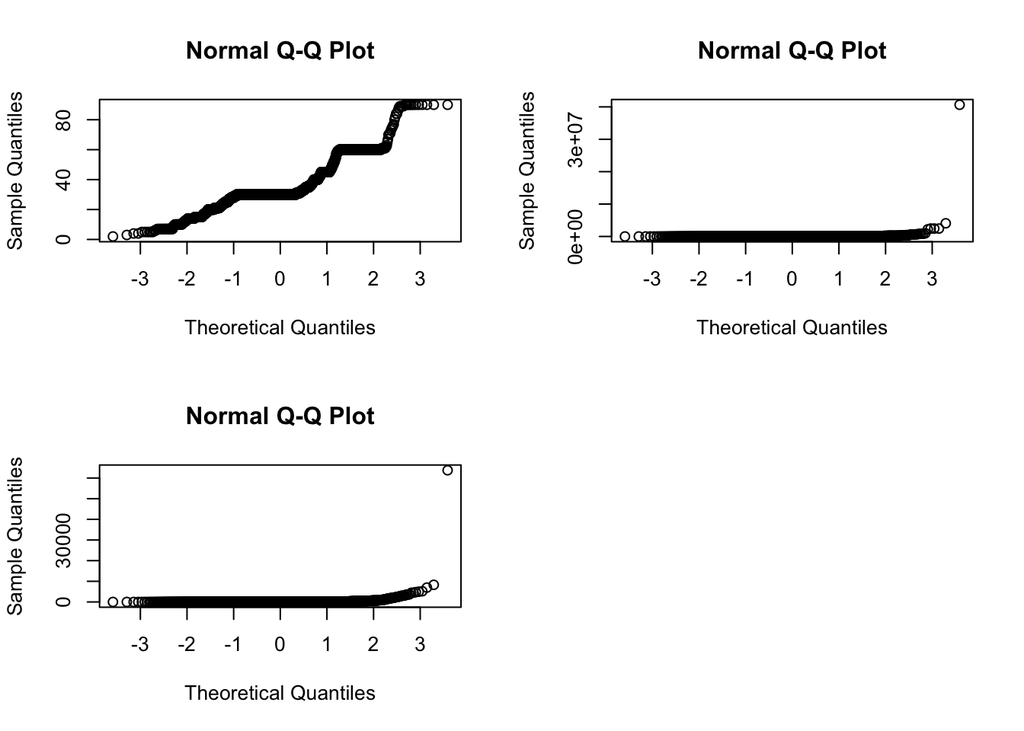

```r
# Representación de la distribución
par(mfrow=c(2,2))
qqnorm(proyect_length)
qqnorm(euros_goal)
qqnorm(backers)
```

Se puede apreciar que los datos no siguen una distribución normal ya que en el total de las comprobaciones el p-valor del Test de Shapiro-Wilk el p-value < 2.2e-16 además que visualemnte se se puede corroborar esto, por lo tanto podemos decir que las variables no siguen una distribución normal.

- Test de homocedasticidad

Ya que hemos comprobado que nuestros datos no siguen una distribución normal (p-value < 2.2e-16 en todos los casos), para el test de homocedasticidad utilizaremos el test de Fligner-Killeen. La hipótesis nula asume la igualdad de varianzas, por lo que p-values inferiores al nivel de significancia (0.05), indicarán heterocedasticidad.

Para ello comprobaremos distintos grupos de datos entre sí:

```r
fligner.test(proyect_length ~ euros_goal, data = dataSet)
```

```
##
##  Fligner-Killeen test of homogeneity of variances
##
## data:  proyect_length by euros_goal
## Fligner-Killeen:med chi-squared = 331.81, df = 376, p-value = 0.951
```

```r
fligner.test(euros_goal ~ backers, data = dataSet)
```

```
##
##  Fligner-Killeen test of homogeneity of variances
##
## data:  euros_goal by backers
## Fligner-Killeen:med chi-squared = 630.07, df = 389, p-value = 1.105e-13
```

```r
fligner.test(proyect_length ~ backers, data = dataSet)
```

```
##
##  Fligner-Killeen test of homogeneity of variances
##
## data:  proyect_length by backers
## Fligner-Killeen:med chi-squared = 300.29, df = 389, p-value = 0.9997
```

De este análisis podemos observar dos casos, para las variables proyect_length-euros_goal y proyect_length-backers el test de Fligner-Killen da un p-value mayor que 0.05 (0.951 y 0.9997 respectivamente), por lo que se asume homocedasticidad.

Por otro lado, la prueba para euros_goal y backers se resuelve con un p-value 1.105e-13, por lo que en este caso si se puede rechazar la hipótesis nula de homocedasticidad y se concluye que la variable euros_goal presenta varianzas estadísticamente diferentes para los diferentes grupos de backers.

## 4.3 Pruebas estadísticas

### 4.3.1 Contraste de hipótesis de dos muestras

Para comprobar si existe relación entre las variables status y main_category, es decir, proyecto fundado exitosamente y tipo categoría vamos a aplicar el test no paramétrico khi cuadrado mediante la función chist.test().

Las hipótesis nula y alternativa quedarían de la siguiente manera:

- Hipótesis nula, H0: el éxito del proyecto y la categoría en la que se encuentre son variables independientes.
- Hipótesis alternativa, H1: existe relación entre la categoría en la que se encuentra un proyecto y el éxito de este.

```r
chisqTable <- table( status, main_category )
chisq.test(chisqTable, correct=FALSE)
```

```
##
##  Pearson's Chi-squared test
##
## data:  chisqTable
## X-squared = 129.27, df = 14, p-value < 2.2e-16
```

Vemos que el p-value resultante del test es < 2.2e-16 por lo que podemos rechazar la hipótesis nula y afirmar, con un 95% de confianza que existe relación significativa entre la categoría en la que se encuentra un proyecto y su éxito o no.

### 4.3.2 Modelo regresión logística simple

En este primero modelo de regresión logística simple se quiere analizar la probabilidad de que un proyecto consiga recaudar los fondos propuestos en base a la longitud establecida.

Como se ha comentado anteriormente, Kickstarter decidió disminuir la duración máxima de los proyectos a 60 días y de hecho recomiendan configurar la campaña para que dure 30 días o menos, ya que la probabilidad de éxito disminuye conforme se alarga el proyecto. Es por ello por lo que queremos comprobar si esto es cierto mediante este modelo.

```r
# Ajuste de un modelo logístico
modelLogisticSimple <- glm(status ~ proyect_length, family = "binomial")
summary(modelLogisticSimple)
```

```
##
## Call:
## glm(formula = status ~ proyect_length, family = "binomial")
##
## Deviance Residuals:
##     Min       1Q   Median       3Q      Max
## -1.2891  -0.9566  -0.8299   1.4157   2.1746
##
## Coefficients:
##                 Estimate Std. Error z value Pr(>|z|)
## (Intercept)     0.316066   0.119579   2.643  0.00821 **
## proyect_length -0.028687   0.003456  -8.302  < 2e-16 ***
## ---
## Signif. codes:  0 '***' 0.001 '**' 0.01 '*' 0.05 '.' 0.1 ' ' 1
##
## (Dispersion parameter for binomial family taken to be 1)
##
##     Null deviance: 3861.9  on 2999  degrees of freedom
## Residual deviance: 3785.5  on 2998  degrees of freedom
## AIC: 3789.5
##
## Number of Fisher Scoring iterations: 4
```

```r
confint(object = modelLogisticSimple, level = 0.95 )
```

```
##                      2.5 %      97.5 %
## (Intercept)     0.08325544  0.55217237
## proyect_length -0.03555386 -0.02200222
```

#### 4.3.2.1 Predicciones

Vamos a comparar probabilidad de que un proyecto sea exitoso cuando la duración de este es de 25 días y cuando es de 45 días y 60 días.

```r
# Predicción para 25 días
round(predict(modelLogisticSimple, data.frame(proyect_length = 25), type="response"), 2)
```

```
##   1
## 0.4
```

```r
# Predicción para 45 días
round(predict(modelLogisticSimple, data.frame(proyect_length = 45), type="response"), 2)
```

```
##    1
## 0.27
```

```r
# Predicción para 60 días
round(predict(modelLogisticSimple, data.frame(proyect_length = 60), type="response"), 2)
```

```
##   1
## 0.2
```

Podemos dar por cierto la afirmación de que a maa2ás largo el proyecto menos probabilidad de éxito hay ya que hemos obtenido que, para los proyectos de 25 días hay un 40% de probabilidad, para los de 45 días un 27% y para los de 60 días un 20%, se aprecia la tendencia a la baja.

### 4.3.3 Modelo de regresión logística múltiple

Vamos a crear un primer modelo predictivo de regresión logística para predecir la expectativa de que un proyecto sea exitoso antes de lanzarlo. Para ello tendremos como variable respuesta status, y como variables explicativas usaremos: main_category, proyect_length, backers y euros_goal.

Vamos a especificar el nivel base de referencia para la variable cualitativa:

- Para la variable main_category, la categoría ‘Dance’.

```r
status <- as.factor(status)
main_category <- as.factor(main_category)

# Nivel de referencia
main_category <- relevel(main_category, ref = 'Dance')

modelLogistic = glm(formula = status ~ main_category + proyect_length +
                    backers + euros_goal, family = binomial(link = logit))
summary(modelLogistic)
```

```
##
## Call:
## glm(formula = status ~ main_category + proyect_length + backers +
##     euros_goal, family = binomial(link = logit))
##
## Deviance Residuals:
##     Min       1Q   Median       3Q      Max
## -8.4904  -0.6031  -0.1044   0.2609   4.5555
##
## Coefficients:
##                             Estimate Std. Error z value Pr(>|z|)
## (Intercept)                3.477e-01  4.834e-01   0.719 0.471938
## main_categoryArt          -3.655e-01  4.922e-01  -0.743 0.457720
## main_categoryComics       -7.867e-01  5.451e-01  -1.443 0.148975
## main_categoryCrafts       -1.148e+00  5.869e-01  -1.957 0.050380 .
## main_categoryDesign       -1.055e+00  5.247e-01  -2.011 0.044309 *
## main_categoryFashion      -8.089e-01  5.148e-01  -1.571 0.116159
## main_categoryFilm & Video -3.991e-01  4.798e-01  -0.832 0.405569
## main_categoryFood         -1.096e+00  5.229e-01  -2.096 0.036111 *
## main_categoryGames        -1.782e+00  5.191e-01  -3.432 0.000598 ***
## main_categoryJournalism   -9.212e-01  6.578e-01  -1.401 0.161357
## main_categoryMusic        -1.391e-01  4.821e-01  -0.288 0.773001
## main_categoryPhotography  -8.319e-01  5.632e-01  -1.477 0.139665
## main_categoryPublishing   -9.017e-01  4.889e-01  -1.845 0.065096 .
## main_categoryTechnology   -8.363e-01  5.280e-01  -1.584 0.113219
## main_categoryTheater      -5.243e-02  5.366e-01  -0.098 0.922166
## proyect_length            -1.605e-02  4.669e-03  -3.438 0.000587 ***
## backers                    3.895e-02  1.862e-03  20.919  < 2e-16 ***
## euros_goal                -2.472e-04  1.537e-05 -16.088  < 2e-16 ***
## ---
## Signif. codes:  0 '***' 0.001 '**' 0.01 '*' 0.05 '.' 0.1 ' ' 1
##
## (Dispersion parameter for binomial family taken to be 1)
##
##     Null deviance: 3861.9  on 2999  degrees of freedom
## Residual deviance: 1965.7  on 2982  degrees of freedom
## AIC: 2001.7
##
## Number of Fisher Scoring iterations: 12
```

```r
# Odds Ratio
exp(coefficients(modelLogistic))
```

```
##               (Intercept)          main_categoryArt       main_categoryComics
##                 1.4158301                 0.6938535                 0.4553503
##       main_categoryCrafts       main_categoryDesign      main_categoryFashion
##                 0.3171124                 0.3480801                 0.4453674
## main_categoryFilm & Video         main_categoryFood        main_categoryGames
##                 0.6709450                 0.3342483                 0.1683337
##   main_categoryJournalism        main_categoryMusic  main_categoryPhotography
##                 0.3980378                 0.8701811                 0.4352336
##   main_categoryPublishing   main_categoryTechnology      main_categoryTheater
##                 0.4058637                 0.4333262                 0.9489238
##            proyect_length                   backers                euros_goal
##                 0.9840785                 1.0397144                 0.9997528
```

```r
exp(confint.default(modelLogistic, level = 0.95))
```

```
##                                2.5 %    97.5 %
## (Intercept)               0.54897116 3.6515121
## main_categoryArt          0.26443859 1.8205840
## main_categoryComics       0.15643816 1.3254047
## main_categoryCrafts       0.10036935 1.0019022
## main_categoryDesign       0.12445863 0.9734943
## main_categoryFashion      0.16236441 1.2216476
## main_categoryFilm & Video 0.26198089 1.7183207
## main_categoryFood         0.11993823 0.9314956
## main_categoryGames        0.06085578 0.4656290
## main_categoryJournalism   0.10965741 1.4448096
## main_categoryMusic        0.33827593 2.2384542
## main_categoryPhotography  0.14431909 1.3125659
## main_categoryPublishing   0.15569239 1.0580177
## main_categoryTechnology   0.15395575 1.2196465
## main_categoryTheater      0.33150745 2.7162477
## proyect_length            0.97511453 0.9931250
## backers                   1.03592755 1.0435152
## euros_goal                0.99972269 0.9997829
```

Observando el sumario del modelo podemos decir que las variables backers, proyect_length y euros_goal son significativas al tener p-values menores que el nivel de significancia 0.05 (< 2e-16, 0.000587 y < 2e-16 respectivamente). La variable proyect_length, como ya sabíamos afecta de forma negativa al éxito del proyecto con un coeficiente asociado igual a -1.605e-02. Por otra parte, la variable backers afecta a al éxito del proyecto de manera positiva 3.895e-02. La variable euros_goal (objetivo económico marcado al que se tiene que llegar antes de que se termine la campaña), afecta de forma negativa a razón de 2.472e-04.

En cuanto a la variable main_category, hemos definido antes que el nivel de referencia es ‘Dance’, si nos fijamos en los OR (odds-ratio) vemos que para el resto las categorías el OR está por debajo de la unidad, lo que indica que es menos probable que un proyecto sea éxitos si pertenece a cualquier otra categoría que si pertenece a Dance.

A modo de nota, se ha probado a introducir la variable country, pero empeoraba el modelo considerablemente, el AIC pasaba a superar los 3700. Además de que todos los p-values para las distintas variables dummy creadas para representar los distintos países estaban por encima de 0.05.

#### 4.3.3.1 Comparación de las predicciones con las observaciones

Para conocer un poco más del modelo crearemos la matriz de confusión y veremos qué porcentaje de observaciones de entrenamiento es capaz de clasificar correctamente el modelo.

```r
predicciones <- ifelse(test = modelLogistic$fitted.values > 0.5, yes = 1, no = 0)
# predicciones
matriz_confusion <- table(modelLogistic$model$status, predicciones,
                           dnn = c("observaciones", "predicciones"))
matriz_confusion
```

```
##              predicciones
## observaciones    0    1
##             0 1896   72
##             1  262  770
```

El modelo es capaz de clasificar correctamente ((1896 + 770) / (1896 + 770 + 262 + 72)) = 0.8886, es decir, el 88.86% de las observaciones de entrenamiento, por lo que se puede considerar bueno.

#### 4.3.3.2 Predicción

```r
predict(modelLogistic, data.frame(main_category = 'Dance', proyect_length = 30,
                                  backers = seq(from = 20, to = 100, by = 20),
                                  euros_goal = 10000), type ="response")
```

```
##         1         2         3         4         5
## 0.1385835 0.2595742 0.4330886 0.6247271 0.7839073
```

La probabilidad, expresada en porcentaje para los valores mencionados anteriormente iría desde 13.85% si hay 20 backers a un 78.39% si los backers son 100.

# 5 Representación de los resultados

- Visualización predictiva de la variable del éxito de un proyecto en base a la variable proyect_length

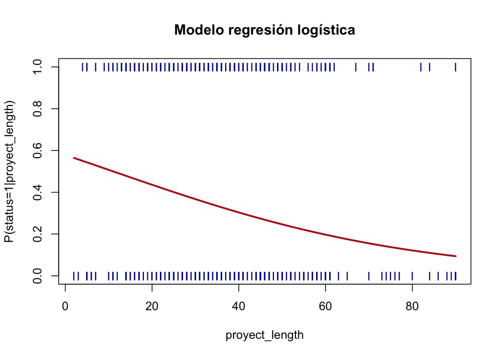

```r
dataSet$status <- as.character(dataSet$status)
dataSet$status <- as.numeric(dataSet$status)

plot(status ~ proyect_length, dataSet, col = "darkblue",
     main = "Modelo regresión logística",
     ylab = "P(status=1|proyect_length)",
     xlab = "proyect_length", pch = "I")

curve(predict(modelLogisticSimple, data.frame(proyect_length = x), type = "response"),
      col = "firebrick", lwd = 2.5, add = TRUE)
```

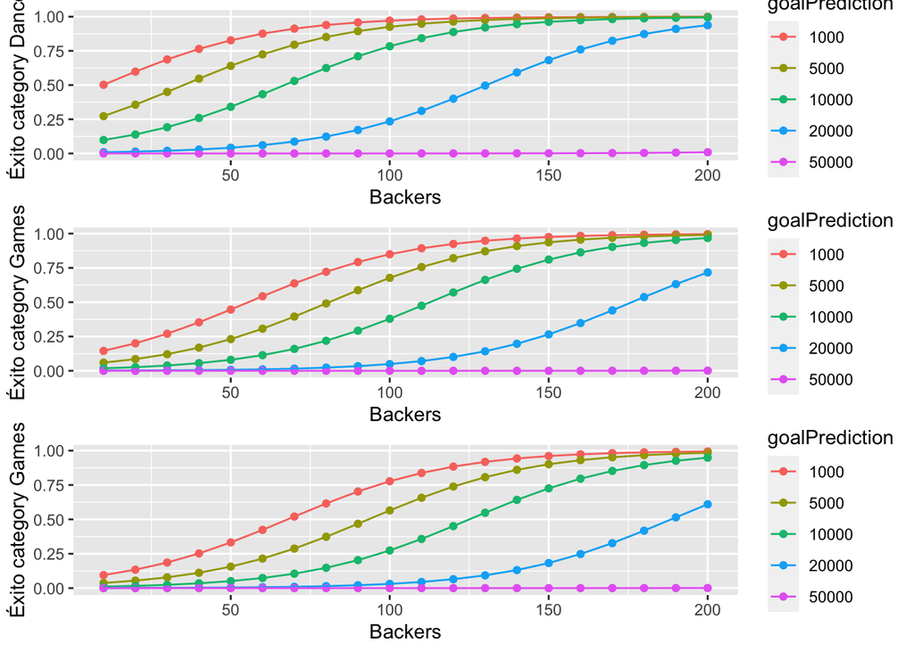

```r
require(gridExtra)
newdata <- data.frame(proyect_length = c(rep(30, 100)),
                       backers = rep(seq(from = 10, to = 200, by = 10), 5),
                       main_category=c(rep('Dance', 100)),
                       euros_goal=c(rep(1000, 20), rep(5000, 20), rep(10000, 20),
                                   rep(20000, 20), rep(50000, 20)))

successPrediction <- predict(modelLogistic, newdata, type="response")
goalPrediction <- as.factor(c(rep(1000, 20), rep(5000, 20), rep(10000, 20),
                     rep(20000, 20), rep(50000, 20)))
backersTotal <- rep(seq(from = 10, to = 200, by = 10), 5)
predictionDataFrame <- data.frame(goalPrediction, successPrediction, backersTotal)

# Gráfica para la categoría Dance
plot1 <- ggplot(predictionDataFrame, aes(x = backersTotal, y = successPrediction,
                                col = goalPrediction))+geom_point()+geom_line()+
                                ylab('Éxito category Dance') + xlab('Backers')

# Gráfica para la categoría Games
newdata$main_category <- c(rep('Games', 100))
successPrediction <- predict(modelLogistic, newdata, type="response")
predictionDataFrame <- data.frame(goalPrediction, successPrediction, backersTotal)
plot2 <- ggplot(predictionDataFrame, aes(x = backersTotal, y = successPrediction,
                                col = goalPrediction))+geom_point()+geom_line()+
                                ylab('Éxito category Games') + xlab('Backers')

# Gráfica para longitud de proyecto 60 días
newdata$proyect_length <- c(rep(60, 100))
successPrediction <- predict(modelLogistic, newdata, type="response")
predictionDataFrame <- data.frame(goalPrediction, successPrediction, backersTotal)
plot3 <- ggplot(predictionDataFrame, aes(x = backersTotal, y = successPrediction,
                                col = goalPrediction))+geom_point()+geom_line()+
                                ylab('Éxito category Games') + xlab('Backers')
grid.arrange(plot1, plot2, plot3, ncol = 1)
```

Al cambiar la categoría observamos que la probabilidad de éxito disminuye, es decir, se necesitan más mecenas por proyecto para que el proyecto sea exitoso. Y lo mismo ocurre si la duración del proyecto se alarga hasta los 60 días.

# 6 Conclusiones

Se ha conseguido crear un modelo que predice que probabilidad tiene un proyecto de conseguir el objetivo monetario propuesto en base a la categoría en la que se incluye el proyecto, la longitud de este, el goal fijado y los mecenas. Cierto es que los mecenas del proyecto es imposible conocerlos de antemano, pero se pueden estimar ciertos valores que nos ayudarán a saber qué cantidad de backers necesitaremos para que nuestro proyecto sea exitoso.

Claramente la categoría a la que pertenece el mismo es un factor que influye en gran medida al igual que el goal propuesto. Se puede ver en las gráficas que a partir de cierto goal la probabilidad disminuye muchísimo.

De entrada, se puede pensar que a más días dure el proyecto mejor, más probabilidad de conseguir mecenas y llegar al objetivo, pero claramente, mediante los modelos y las gráficas se puede observar que esto no es así, sino todo lo contrario.

# 7 Agradecimientos

En primer lugar, agradecer y reconocer el trabajo de Mickaël Mouillé **[enalce]**(https://www.kaggle.com/kemical), creador del dataset por trabajo para recolectar datos durante tantos años y publicarlos para el uso público.

También agradecer a todas aquellas personas que han publicado sus dudas sobre el dataset en beneficio de todos.

# 8 Tabla de contribuciones

| Contribuciones | Firma |
| --- | --- |
| Investigación previa | M.G. |
| Redacción de las respuestas | M.G. |
| Desarrollo código | M.G. |